# spotify

## Spotify Data Scientist

Sean Chang

The goal of this assignment is to demonstrate your ability to derive meaningful insights from a realworld data set, to communicate and contextualize findings, and, most importantly, to showcase your creativity and analytical rigor in generating and testing hypotheses.

The assignment is intentionally unspecific and exploratory in nature; your task is to formulate a clear research framework, questions, and findings.The data set at hand covers passenger airline travel within the United States from 1987 to the present and can be accessed here. We've also attached additiona data on carriers and airport locations. We encourage you to merge the air traffic data with other data sets to contextualize your investigation. Mindful of the time we are giving you to complete this assignment, we recommend somewhat narrowly focusing your investigation.

We're looking for a few page document that summarizes your investigation and your findings.

http://www.transtats.bts.gov/DL_SelectFields.asp?Table_ID=236&DB_Short_Name=On-Time

airport weather data (Agron) https://mesonet.agron.iastate.edu/ogc/

Q1a: predict the arrival time before the flight date?

Q1b: predict the arrival time given airport situation & weather on the date

Q2: predict the cancellation rat (very low)

```python
import pandas as pd
import random
import scipy as sp
import numpy as np
import matplotlib.pyplot as plt
%matplotlib inline
import seaborn as sns
sns.set(style="darkgrid")
import os

os.chdir('/home/sc268/Dropbox/codes/2016_spotify/')
#os.chdir('/Users/pingpong3mike/Dropbox/codes/2016_spotify/')

print os.getcwd()
```

```
/home/sc268/Dropbox/codes/2016_spotify
```

```python
#dat = pd.read_csv('/home/sc268/Documents/topairports.csv')
```

## EDA

```python
print dat.shape
dat.head()
```

```
(204332, 24)
```

|  | DayOfWeek | FlightDate | UniqueCarrier | TailNum | FlightNum | Origin | Dest | CRSDepTime | DepTime | DepDelay | ... | Diverted | CRSElapsedTime | ActualElapsedTime | AirTime | Distance | CarrierDelay | WeatherDelay | NASDelay | SecurityDelay | LateAircraftDelay |
| --- | --- | --- | --- | --- | --- | --- | --- | --- | --- | --- | --- | --- | --- | --- | --- | --- | --- | --- | --- | --- | --- |
| 0 | 2 | 2014-10-21 | DL | N902DE | 1977 | ATL | ORD | 1612 | 1630 | 18 | ... | 0 | 124 | 137 | 113 | 606 | 18 | 0 | 13 | 0 | 0 |
| 1 | 2 | 2014-10-21 | DL | N902DE | 1977 | ORD | ATL | 1800 | 1841 | 41 | ... | 0 | 118 | 99 | 90 | 606 | 5 | 0 | 0 | 0 | 17 |
| 2 | 2 | 2014-10-21 | DL | N893AT | 2012 | ATL | ORD | 728 | 727 | -1 | ... | 0 | 118 | 128 | 107 | 606 | NaN | NaN | NaN | NaN | NaN |
| 3 | 2 | 2014-10-21 | DL | N910DL | 2043 | JFK | ATL | 1305 | 1306 | 1 | ... | 0 | 149 | 154 | 107 | 760 | NaN | NaN | NaN | NaN | NaN |
| 4 | 2 | 2014-10-21 | DL | N944DL | 2044 | JFK | ATL | 1925 | 1952 | 27 | ... | 0 | 163 | 130 | 107 | 760 | NaN | NaN | NaN | NaN | NaN |

5 rows × 24 columns

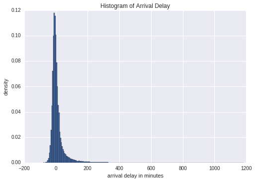

```python
weights = np.ones_like(dat.ArrDelay.dropna()) / len(dat.ArrDelay.dropna())
plt.hist(dat.ArrDelay.dropna(), bins=250, weights= weights)
#weights = np.ones_like(dat.DepDelay.dropna()) / len(dat.DepDelay.dropna())
#plt.hist(dat.DepDelay.dropna(), bins=500, weights= weights)
plt.xlabel('arrival delay in minutes')
plt.ylabel('density')
plt.title('Histogram of Arrival Delay')
plt.show()
```

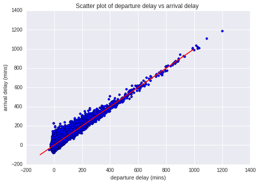

```python
plt.scatter(dat.DepDelay, dat.ArrDelay)
plt.ylabel('arrival delay (mins)')
plt.xlabel('departure delay (mins)')
plt.plot(range(-100, 1000), range(-100,1000), 'red')
plt.title('Scatter plot of departure delay vs arrival delay ')
plt.show()
```

```python
for columnname in dat.columns:
    print '"' + columnname + '",' ,
```

[output not shown]

```python
#sample 8 %
idx = np.random.choice(dat.index, size = int(len(dat)*0.08), replace = False)
dat =   dat.ix[idx].reset_index(drop=True)
print dat.shape
```

```
(16346, 24)
```

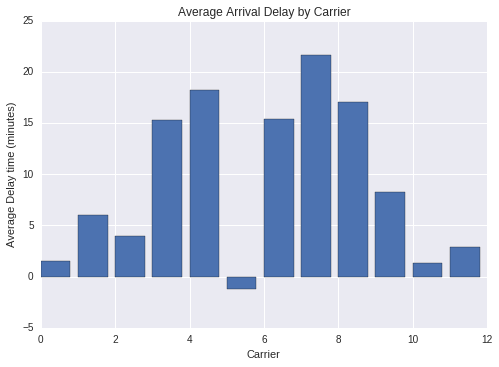

```python
#average flight delay by flight number
res = dat.ArrDelay.groupby(dat.UniqueCarrier).mean()
idx = res.index

plt.bar(np.arange(len(idx)), res.values)
plt.xlabel('Carrier')
plt.ylabel('Average Delay time (minutes)')
plt.title('Average Arrival Delay by Carrier')
```

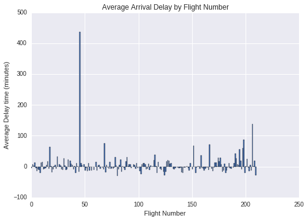

```python
#average flight delay by flight number
res = dat.ArrDelay.groupby(dat.FlightNum).mean()
idx = res.index

plt.bar(np.arange(len(idx)), res.values)
plt.xlabel('Flight Number')
plt.ylabel('Average Delay time (minutes)')
plt.title('Average Arrival Delay by Flight Number')
```